# ProjectSubmissionSupervised

**1. Read the column description and ensure you understand each attribute well**

```python
import numpy as np
import pandas as pd
import matplotlib.pyplot as plt
%matplotlib inline
import seaborn as sns
```

```python
missing_values=["n/a","na","--","&","/","?"]
dataset=pd.read_csv("Bank_Personal_Loan_Modelling.csv",na_values=missing_values)
dataset.head()
```

|  | ID | Age | Experience | Income | ZIP Code | Family | CCAvg | Education | Mortgage | Personal Loan | Securities Account | CD Account | Online | CreditCard |
| --- | --- | --- | --- | --- | --- | --- | --- | --- | --- | --- | --- | --- | --- | --- |
| 0 | 1 | 25 | 1 | 49 | 91107 | 4 | 1.6 | 1 | 0 | 0 | 1 | 0 | 0 | 0 |
| 1 | 2 | 45 | 19 | 34 | 90089 | 3 | 1.5 | 1 | 0 | 0 | 1 | 0 | 0 | 0 |
| 2 | 3 | 39 | 15 | 11 | 94720 | 1 | 1.0 | 1 | 0 | 0 | 0 | 0 | 0 | 0 |
| 3 | 4 | 35 | 9 | 100 | 94112 | 1 | 2.7 | 2 | 0 | 0 | 0 | 0 | 0 | 0 |
| 4 | 5 | 35 | 8 | 45 | 91330 | 4 | 1.0 | 2 | 0 | 0 | 0 | 0 | 0 | 1 |

```python
numerical = [
  'ID','Age','Experience', 'Income', 'ZIP Code', 'Family', 'CCAvg', 'Education', 'Mortgage','Securities Account','CD Account','Online','CreditCard','Personal Loan'
]
```

```python
dataset=dataset[numerical]
dataset.shape
```

```
(5000, 14)
```

```python
dataset.info()
```

```
<class 'pandas.core.frame.DataFrame'>
RangeIndex: 5000 entries, 0 to 4999
Data columns (total 14 columns):
ID                    5000 non-null int64
Age                   5000 non-null int64
Experience            5000 non-null int64
Income                5000 non-null int64
ZIP Code              5000 non-null int64
Family                5000 non-null int64
CCAvg                 5000 non-null float64
Education             5000 non-null int64
Mortgage              5000 non-null int64
Securities Account    5000 non-null int64
CD Account            5000 non-null int64
Online                5000 non-null int64
CreditCard            5000 non-null int64
Personal Loan         5000 non-null int64
dtypes: float64(1), int64(13)
memory usage: 547.0 KB
```

```python
dataset.describe()
```

|  | ID | Age | Experience | Income | ZIP Code | Family | CCAvg | Education | Mortgage | Securities Account | CD Account | Online | CreditCard | Personal Loan |
| --- | --- | --- | --- | --- | --- | --- | --- | --- | --- | --- | --- | --- | --- | --- |
| count | 5000.000000 | 5000.000000 | 5000.000000 | 5000.000000 | 5000.000000 | 5000.000000 | 5000.000000 | 5000.000000 | 5000.000000 | 5000.000000 | 5000.00000 | 5000.000000 | 5000.000000 | 5000.000000 |
| mean | 2500.500000 | 45.338400 | 20.104600 | 73.774200 | 93152.503000 | 2.396400 | 1.937938 | 1.881000 | 56.498800 | 0.104400 | 0.06040 | 0.596800 | 0.294000 | 0.096000 |
| std | 1443.520003 | 11.463166 | 11.467954 | 46.033729 | 2121.852197 | 1.147663 | 1.747659 | 0.839869 | 101.713802 | 0.305809 | 0.23825 | 0.490589 | 0.455637 | 0.294621 |
| min | 1.000000 | 23.000000 | -3.000000 | 8.000000 | 9307.000000 | 1.000000 | 0.000000 | 1.000000 | 0.000000 | 0.000000 | 0.00000 | 0.000000 | 0.000000 | 0.000000 |
| 25% | 1250.750000 | 35.000000 | 10.000000 | 39.000000 | 91911.000000 | 1.000000 | 0.700000 | 1.000000 | 0.000000 | 0.000000 | 0.00000 | 0.000000 | 0.000000 | 0.000000 |
| 50% | 2500.500000 | 45.000000 | 20.000000 | 64.000000 | 93437.000000 | 2.000000 | 1.500000 | 2.000000 | 0.000000 | 0.000000 | 0.00000 | 1.000000 | 0.000000 | 0.000000 |
| 75% | 3750.250000 | 55.000000 | 30.000000 | 98.000000 | 94608.000000 | 3.000000 | 2.500000 | 3.000000 | 101.000000 | 0.000000 | 0.00000 | 1.000000 | 1.000000 | 0.000000 |
| max | 5000.000000 | 67.000000 | 43.000000 | 224.000000 | 96651.000000 | 4.000000 | 10.000000 | 3.000000 | 635.000000 | 1.000000 | 1.00000 | 1.000000 | 1.000000 | 1.000000 |

```python
dataset.isnull().sum()
```

```
ID                    0
Age                   0
Experience            0
Income                0
ZIP Code              0
Family                0
CCAvg                 0
Education             0
Mortgage              0
Securities Account    0
CD Account            0
Online                0
CreditCard            0
Personal Loan         0
dtype: int64
```

```python
dataset.columns
```

```
Index(['ID', 'Age', 'Experience', 'Income', 'ZIP Code', 'Family', 'CCAvg',
       'Education', 'Mortgage', 'Securities Account', 'CD Account', 'Online',
       'CreditCard', 'Personal Loan'],
      dtype='object')
```

```python
dataset.index.values
```

```
array([   0,    1,    2, ..., 4997, 4998, 4999], dtype=int64)
```

```python
dataset.isna().sum()
```

```
ID                    0
Age                   0
Experience            0
Income                0
ZIP Code              0
Family                0
CCAvg                 0
Education             0
Mortgage              0
Securities Account    0
CD Account            0
Online                0
CreditCard            0
Personal Loan         0
dtype: int64
```

```python
dataset=dataset.replace('?',np.nan)
dataset=dataset.apply(lambda x:x.fillna(x.median()),axis=0)
```

```python
dataset.info()
```

```
<class 'pandas.core.frame.DataFrame'>
RangeIndex: 5000 entries, 0 to 4999
Data columns (total 14 columns):
ID                    5000 non-null int64
Age                   5000 non-null int64
Experience            5000 non-null int64
Income                5000 non-null int64
ZIP Code              5000 non-null int64
Family                5000 non-null int64
CCAvg                 5000 non-null float64
Education             5000 non-null int64
Mortgage              5000 non-null int64
Securities Account    5000 non-null int64
CD Account            5000 non-null int64
Online                5000 non-null int64
CreditCard            5000 non-null int64
Personal Loan         5000 non-null int64
dtypes: float64(1), int64(13)
memory usage: 547.0 KB
```

**2. Study the data distribution in each attribute, share your findings**

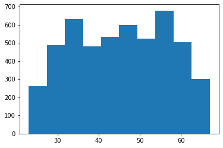

```python
# ploting
plt.hist(dataset['Age'])
```

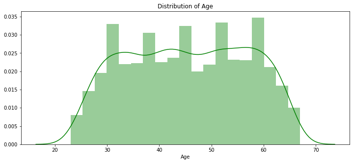

```python
"""
Individual distibution of Age
"""
plt.figure(figsize=(12,5))
plt.title("Distribution of Age")
ax = sns.distplot(dataset["Age"], color = 'g')
```

```python
dataset['Age'].describe()
```

```
count    5000.000000
mean       45.338400
std        11.463166
min        23.000000
25%        35.000000
50%        45.000000
75%        55.000000
max        67.000000
Name: Age, dtype: float64
```

```python
dataset['Age'].isnull().sum()
```

```
0
```

```python
pd.qcut(dataset['Age'], q=4)
```

```
0       (22.999, 35.0]
1         (35.0, 45.0]
2         (35.0, 45.0]
3       (22.999, 35.0]
4       (22.999, 35.0]
5         (35.0, 45.0]
6         (45.0, 55.0]
7         (45.0, 55.0]
8       (22.999, 35.0]
9       (22.999, 35.0]
10        (55.0, 67.0]
11      (22.999, 35.0]
12        (45.0, 55.0]
13        (55.0, 67.0]
14        (55.0, 67.0]
```

[output cut: 48 more lines]

```python
dataset['Age'].value_counts()
```

```
35    151
43    149
52    145
58    143
54    143
50    138
41    136
30    136
56    135
34    134
39    133
59    132
57    132
51    129
60    127
```

[output cut: 31 more lines]

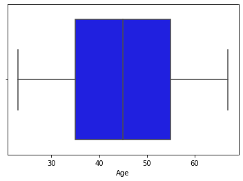

```python
sns.boxplot(dataset['Age'],color='b')
```

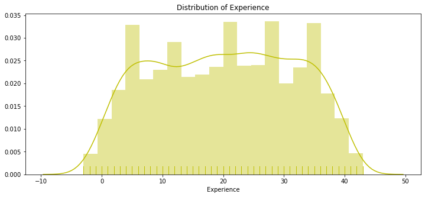

```python
plt.figure(figsize=(12,5))
sns.distplot(dataset['Experience'],color = 'y',rug=True)
plt.title('Distribution of Experience')
plt.show()
```

```python
# Negative values are there.
dataset['Experience'].value_counts()
```

```
 32    154
 20    148
 9     147
 5     146
 23    144
 35    143
 25    142
 28    138
 18    137
 19    135
 26    134
 24    131
 3     129
 14    127
 16    127
```

[output cut: 33 more lines]

```python
dataset['Experience'].describe()
```

```
count    5000.000000
mean       20.104600
std        11.467954
min        -3.000000
25%        10.000000
50%        20.000000
75%        30.000000
max        43.000000
Name: Experience, dtype: float64
```

```python
dataset['Experience'].isnull().sum()
```

```
0
```

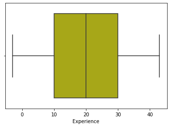

```python
sns.boxplot(dataset['Experience'],color='y')
```

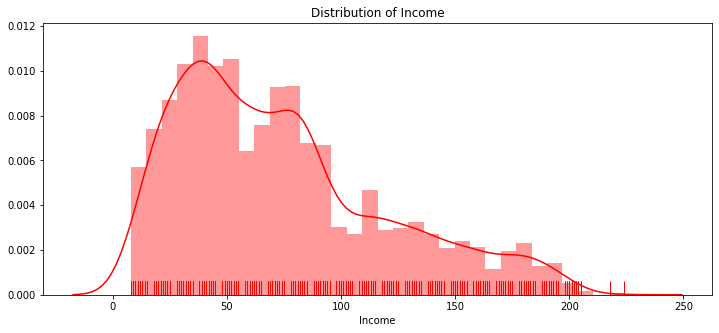

```python
plt.figure(figsize=(12,5))
sns.distplot(dataset['Income'],color = 'r',rug=True)
plt.title('Distribution of Income')
```

```python
dataset['Income'].value_counts()
```

```
44     85
38     84
81     83
41     82
39     81
40     78
42     77
83     74
43     70
45     69
29     67
21     65
35     65
22     65
85     65
```

[output cut: 47 more lines]

```python
dataset['Income'].isnull().sum()
```

```
0
```

```python
dataset['Income'].describe()
```

```
count    5000.000000
mean       73.774200
std        46.033729
min         8.000000
25%        39.000000
50%        64.000000
75%        98.000000
max       224.000000
Name: Income, dtype: float64
```

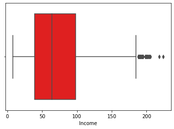

```python
sns.boxplot(dataset['Income'],color='r')
plt.show()
```

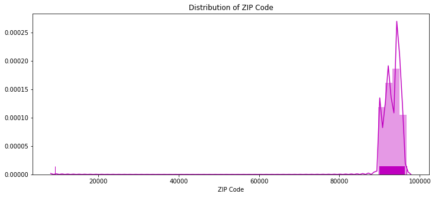

```python
plt.figure(figsize=(12,5))
sns.distplot(dataset['ZIP Code'],color = 'm',rug=True)
plt.title('Distribution of ZIP Code')
```

```python
dataset['ZIP Code'].describe()
```

```
count     5000.000000
mean     93152.503000
std       2121.852197
min       9307.000000
25%      91911.000000
50%      93437.000000
75%      94608.000000
max      96651.000000
Name: ZIP Code, dtype: float64
```

```python
dataset['ZIP Code'].value_counts()
```

```
94720    169
94305    127
95616    116
90095     71
93106     57
92037     54
93943     54
91320     53
91711     52
94025     52
92093     51
90245     50
90024     50
90089     46
91330     46
```

[output cut: 47 more lines]

```python
dataset['ZIP Code'].isnull().sum()
```

```
0
```

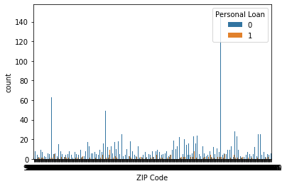

```python
sns.countplot(x='ZIP Code',data=dataset,hue='Personal Loan')
```

```python
sns.catplot(x="ZIP Code", y="survived", col="class",
               data=titanic, saturation=.5,
            kind="bar", ci=None, aspect=.6)
```

[output not shown]

```python
sns.boxplot(dataset['ZIP Code'],color='m')
plt.show()
```

[output not shown]

```python
plt.figure(figsize=(12,5))
sns.distplot(dataset['Family'],color = 'g',rug=True)
plt.title('Distribution of Family')
plt.show()
```

[output not shown]

```python
dataset['Family'].value_counts()
```

[output not shown]

```python
dataset['Family'].describe()
```

[output not shown]

```python
dataset['Family'].isnull().sum()
```

[output not shown]

Family is a categorical variable.  
Family doesn't contains negative values.  
No null values

```python
sns.boxplot(dataset['Family'],color='g')
plt.show()
```

[output not shown]

```python
plt.figure(figsize=(12,5))
sns.distplot(dataset['CCAvg'],color = 'b',rug=True)
plt.title('Distribution of CCAvg')
plt.show()
```

[output not shown]

```python
dataset['CCAvg'].value_counts()
```

[output not shown]

```python
dataset['CCAvg'].describe()
```

[output not shown]

```python
dataset['CCAvg'].isnull().sum()
```

[output not shown]

```python
sns.boxplot(y=dataset['CCAvg'],color='b')
plt.title('Distribution of CCAvg ')
plt.show()
```

[output not shown]

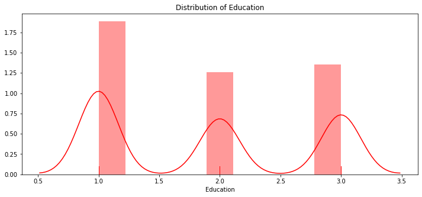

```python
plt.figure(figsize=(12,5))
sns.distplot(dataset['Education'],color = 'r',rug=True)
plt.title('Distribution of Education')
plt.show()
```

```python
dataset['Education'].value_counts()
```

```
1    2096
3    1501
2    1403
Name: Education, dtype: int64
```

```python
dataset['Education'].describe()
```

```
count    5000.000000
mean        1.881000
std         0.839869
min         1.000000
25%         1.000000
50%         2.000000
75%         3.000000
max         3.000000
Name: Education, dtype: float64
```

```python
dataset['Education'].isnull().sum()
```

```
0
```

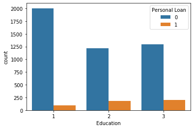

```python
sns.countplot(x='Education',data=dataset,hue='Personal Loan')
```

Education is a categorical variable.  
People who comes under category of Education level=1,have taken less personal loans as compare to people with higher Education.  
Education doesn't contains negative values.  
No null values

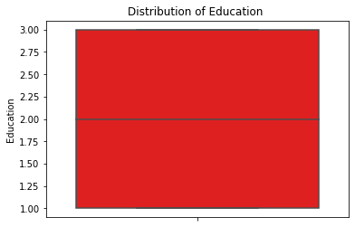

```python
sns.boxplot(y=dataset['Education'],color='r')
plt.title('Distribution of Education ')
plt.show()
```

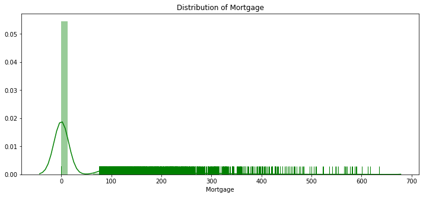

```python
plt.figure(figsize=(12,5))
sns.distplot(dataset['Mortgage'],color = 'g',rug=True)
plt.title('Distribution of Mortgage')
plt.show()
```

```python
dataset['Mortgage'].value_counts()
```

```
0      3462
98       17
103      16
119      16
83       16
91       16
89       16
90       15
102      15
78       15
118      14
101      14
87       14
94       14
131      14
```

[output cut: 47 more lines]

```python
dataset['Mortgage'].describe()
```

```
count    5000.000000
mean       56.498800
std       101.713802
min         0.000000
25%         0.000000
50%         0.000000
75%       101.000000
max       635.000000
Name: Mortgage, dtype: float64
```

```python
dataset['Mortgage'].isnull().sum()
```

```
0
```

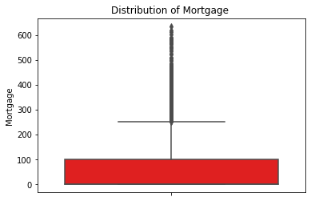

```python
sns.boxplot(y=dataset['Mortgage'],color='r')
plt.title('Distribution of Mortgage ')
plt.show()
```

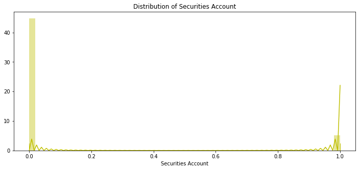

```python
plt.figure(figsize=(12,5))
sns.distplot(dataset['Securities Account'],color = 'y',rug=True)
plt.title('Distribution of Securities Account')
plt.show()
```

```python
dataset['Securities Account'].value_counts()
```

```
0    4478
1     522
Name: Securities Account, dtype: int64
```

```python
dataset['Securities Account'].describe()
```

```
count    5000.000000
mean        0.104400
std         0.305809
min         0.000000
25%         0.000000
50%         0.000000
75%         0.000000
max         1.000000
Name: Securities Account, dtype: float64
```

```python
dataset['Securities Account'].value_counts()
```

```
0    4478
1     522
Name: Securities Account, dtype: int64
```

```python
dataset['Securities Account'].isnull().sum()
```

```
0
```

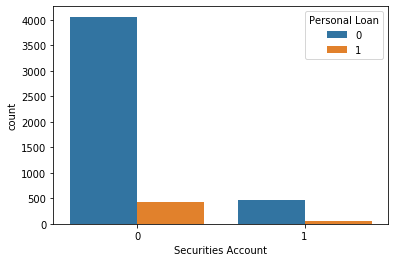

```python
sns.countplot(x='Securities Account',hue='Personal Loan',data=dataset)
```

Securities Account is a categorical variable.  
People with security account as 0 are more than as compare to SA=1.  
Securities Account doesn't contains negative values.  
No null values

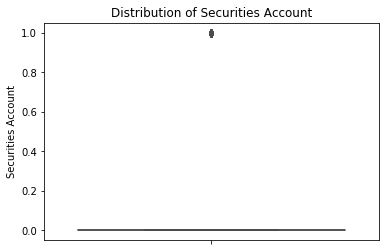

```python
sns.boxplot(y=dataset['Securities Account'],color='r')
plt.title('Distribution of Securities Account')
plt.show()
```

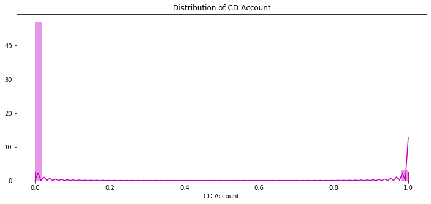

```python
plt.figure(figsize=(12,5))
sns.distplot(dataset['CD Account'],color = 'm',rug=True)
plt.title('Distribution of CD Account')
plt.show()
```

```python
dataset['CD Account'].value_counts()
```

```
0    4698
1     302
Name: CD Account, dtype: int64
```

```python
dataset['CD Account'].describe()
```

```
count    5000.00000
mean        0.06040
std         0.23825
min         0.00000
25%         0.00000
50%         0.00000
75%         0.00000
max         1.00000
Name: CD Account, dtype: float64
```

```python
dataset['CD Account'].value_counts()
```

```
0    4698
1     302
Name: CD Account, dtype: int64
```

```python
dataset['CD Account'].isnull().sum()
```

```
0
```

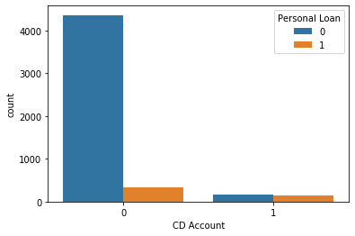

```python
sns.countplot(x='CD Account',hue='Personal Loan',data=dataset)
```

CD Account is a categorical variable.  
CD Account with value=0 are in majority as compare to CD Account=1.  
CD Account doesn't contains negative values.  
No null values

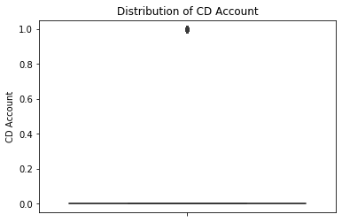

```python
sns.boxplot(y=dataset['CD Account'],color='m')
plt.title('Distribution of CD Account')
plt.show()
```

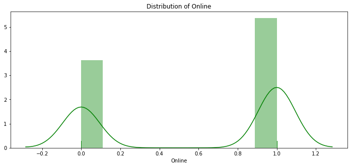

```python
plt.figure(figsize=(12,5))
sns.distplot(dataset['Online'],color = 'g',rug=True)
plt.title('Distribution of Online')
plt.show()
```

```python
dataset['Online'].value_counts()
```

```
1    2984
0    2016
Name: Online, dtype: int64
```

```python
dataset['Online'].describe()
```

```
count    5000.000000
mean        0.596800
std         0.490589
min         0.000000
25%         0.000000
50%         1.000000
75%         1.000000
max         1.000000
Name: Online, dtype: float64
```

```python
dataset['Online'].value_counts()
```

```
1    2984
0    2016
Name: Online, dtype: int64
```

```python
dataset['Online'].isnull().sum()
```

```
0
```

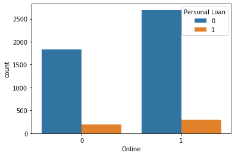

```python
sns.countplot(x='Online',hue='Personal Loan',data=dataset)
```

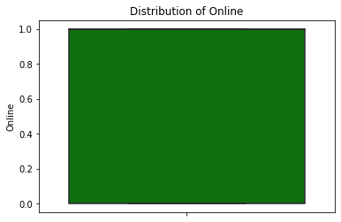

```python
sns.boxplot(y=dataset['Online'],color='g')
plt.title('Distribution of Online')
plt.show()
```

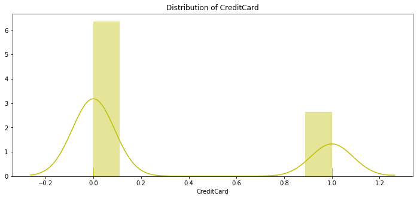

```python
plt.figure(figsize=(12,5))
sns.distplot(dataset['CreditCard'],color = 'y',rug=True)
plt.title('Distribution of CreditCard')
plt.show()
```

```python
dataset['CreditCard'].value_counts()
```

```
0    3530
1    1470
Name: CreditCard, dtype: int64
```

```python
dataset['CreditCard'].describe()
```

```
count    5000.000000
mean        0.294000
std         0.455637
min         0.000000
25%         0.000000
50%         0.000000
75%         1.000000
max         1.000000
Name: CreditCard, dtype: float64
```

```python
dataset['CreditCard'].value_counts()
```

```
0    3530
1    1470
Name: CreditCard, dtype: int64
```

```python
dataset['CreditCard'].isnull().sum()
```

```
0
```

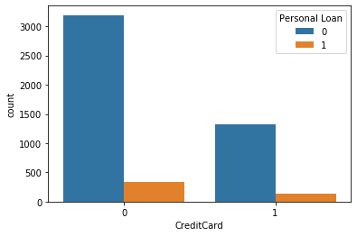

```python
sns.countplot(x='CreditCard',hue='Personal Loan',data=dataset)
```

CreditCard is a categorical variable.  
People with no credit card are more as compare to people having credit card.  
CreditCard doesn't contains negative values.  
No null values

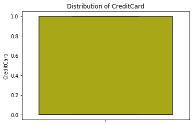

```python
sns.boxplot(y=dataset['CreditCard'],color='y')
plt.title('Distribution of CreditCard')
plt.show()
```

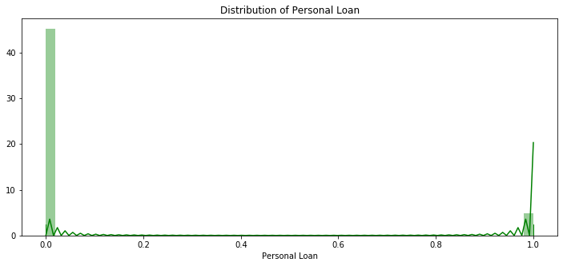

```python
plt.figure(figsize=(12,5))
sns.distplot(dataset['Personal Loan'],color = 'g',rug=True)
plt.title('Distribution of Personal Loan')
plt.show()
```

```python
dataset['Personal Loan'].value_counts()
```

```
0    4520
1     480
Name: Personal Loan, dtype: int64
```

```python
dataset['Personal Loan'].describe()
```

```
count    5000.000000
mean        0.096000
std         0.294621
min         0.000000
25%         0.000000
50%         0.000000
75%         0.000000
max         1.000000
Name: Personal Loan, dtype: float64
```

```python
dataset['Personal Loan'].value_counts()
```

```
0    4520
1     480
Name: Personal Loan, dtype: int64
```

```python
dataset['Personal Loan'].isnull().sum()
```

```
0
```

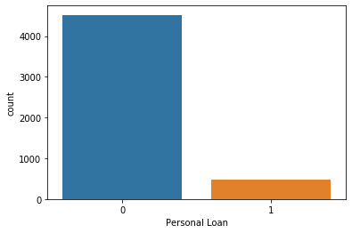

```python
sns.countplot(x='Personal Loan',data=dataset)
```

*3. Get the target column distribution. Your comments*

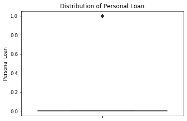

```python
sns.boxplot(y=dataset['Personal Loan'],color='g')
plt.title('Distribution of Personal Loan')
plt.show()
```

Personal Loan is categorical variable.  
People with no personal loan are more as compare to people having personal loan.  
Personal Loan doesn't contains negative values.  
No null values.

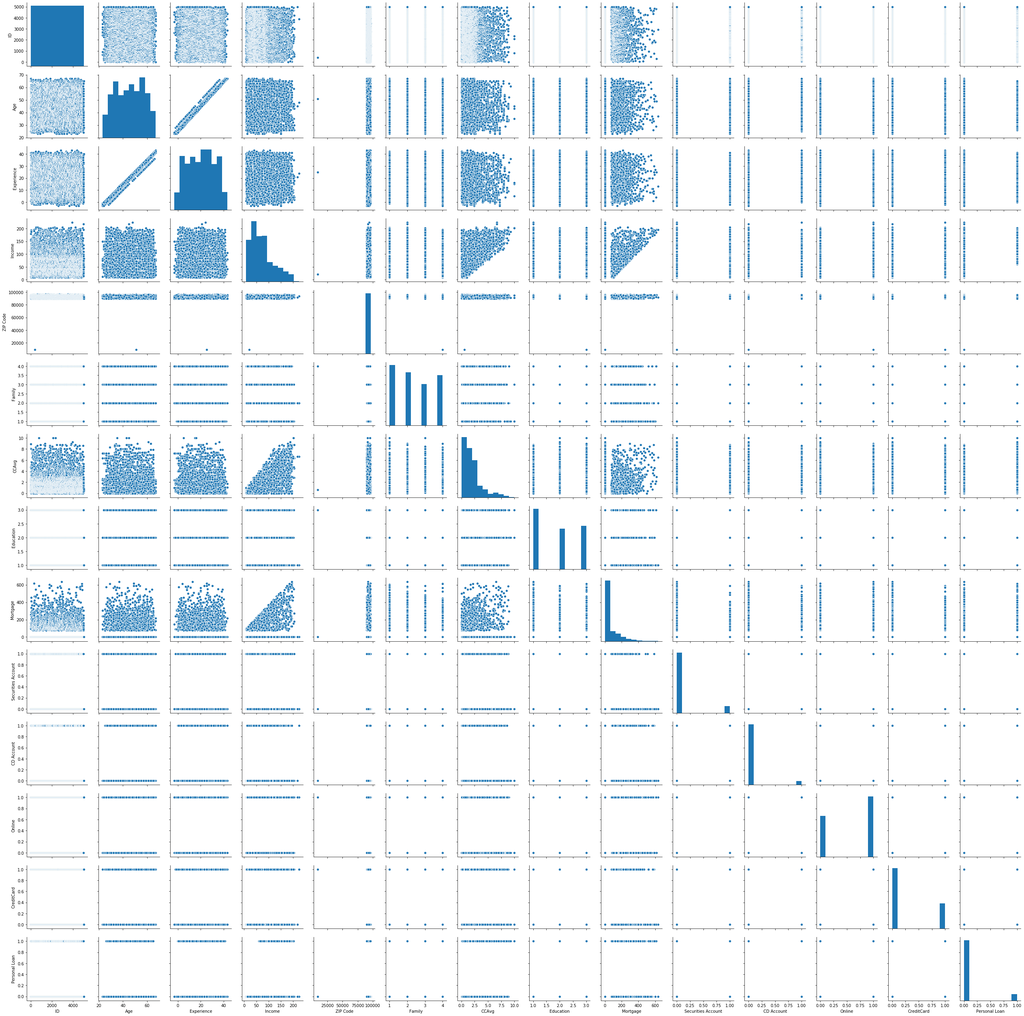

```python
sns.pairplot(dataset)
```